# Structural Equation Models 2019

Mikko Patronen

06 March, 2019

## Week 1

#### Exercise 1.2

#### a) LINEAR REGRESSION

In this exercise a linear regression model was built for one continuous observed dependent variable (y1) with two covariates (x1 and x3). The data “ex3.1” was first manually imported into R and saved as .Rdata -file with R code lines:

df <- ex3.1

save(df, file=“df.Rdata”)

Here is a summary of the variables:

```r
load("df.Rdata")
summary(df)
```

```
##        V1                V2                  V3
##  Min.   :-4.1163   Min.   :-3.145148   Min.   :-3.13875
##  1st Qu.:-0.5269   1st Qu.:-0.749801   1st Qu.:-0.75466
##  Median : 0.4288   Median : 0.023194   Median :-0.04029
##  Mean   : 0.4848   Mean   : 0.001289   Mean   :-0.04216
##  3rd Qu.: 1.5721   3rd Qu.: 0.755620   3rd Qu.: 0.71940
##  Max.   : 5.1110   Max.   : 2.920440   Max.   : 2.87514
```

Then a model was built according to instructions (y1 is the dependent variable, x1 and x3 are independent explanatory variables):

```r
y1 <- df$V1
x1 <- df$V2
x3 <- df$V3

model <- lm(y1 ~ x1 + x3)
summary(model)
```

```
##
## Call:
## lm(formula = y1 ~ x1 + x3)
##
## Residuals:
##     Min      1Q  Median      3Q     Max
## -3.1506 -0.5752  0.0235  0.5663  3.1899
##
## Coefficients:
##             Estimate Std. Error t value Pr(>|t|)
## (Intercept)  0.51096    0.04356   11.73   <2e-16 ***
## x1           0.96949    0.04163   23.29   <2e-16 ***
## x3           0.64904    0.04451   14.58   <2e-16 ***
## ---
## Signif. codes:  0 '***' 0.001 '**' 0.01 '*' 0.05 '.' 0.1 ' ' 1
##
## Residual standard error: 0.9731 on 497 degrees of freedom
## Multiple R-squared:  0.609,  Adjusted R-squared:  0.6075
## F-statistic: 387.1 on 2 and 497 DF,  p-value: < 2.2e-16
```

According to the results both covariates x1 and x3 are statistically significant (p < 0.001). They both have a positive effect on the variable y1: when x1 increases one unit, the variable y1 increases 0.97 units (when x3 is considered a constant) and when x3 increases one unit, the variable y1 increases 0.65 units (when x1 is considered a constant). The model explains around 60% of the variance in the variable y1 (Adjusted R-squared = 0.6075).

Here is a graph of the model (drawn with Affinity Designer):

[figure not shown]

#### b) EXPLORATORY FACTOR ANALYSIS

In this part an exploratory factor analysis is conducted according to instructions. The data file “ex4.1a” was imported manually into R and then wrangled so that the analysis could be run. The wrangling code is here:

df2 <- ex4.1a

colnames(df2) <- c(“y1”, “y2”, “y3”, “y4”, “y5”, “y6”, “y7”, “y8”, “y9”, “y10”, “y11”, “y12”)

save(df2, file=“df2.Rdata”)

Let us view a summary of the data:

```r
load("df2.Rdata")
dim(df2)
```

```
## [1] 500  12
```

```r
summary(df2)
```

```
##        y1                  y2                 y3
##  Min.   :-2.886760   Min.   :-3.69059   Min.   :-2.588919
##  1st Qu.:-0.682516   1st Qu.:-0.61723   1st Qu.:-0.673121
##  Median : 0.013133   Median : 0.06940   Median :-0.071101
##  Mean   : 0.008001   Mean   : 0.03339   Mean   : 0.003162
##  3rd Qu.: 0.700274   3rd Qu.: 0.69136   3rd Qu.: 0.689685
##  Max.   : 2.529128   Max.   : 2.79520   Max.   : 2.967696
##        y4                  y5                 y6
##  Min.   :-3.214602   Min.   :-2.94869   Min.   :-2.500254
##  1st Qu.:-0.577758   1st Qu.:-0.56400   1st Qu.:-0.630876
##  Median :-0.006558   Median : 0.04973   Median :-0.007958
##  Mean   : 0.073489   Mean   : 0.06330   Mean   : 0.062216
##  3rd Qu.: 0.768797   3rd Qu.: 0.76779   3rd Qu.: 0.792593
##  Max.   : 2.892782   Max.   : 3.74102   Max.   : 3.253644
##        y7                  y8                  y9
##  Min.   :-2.798568   Min.   :-3.581810   Min.   :-2.76235
##  1st Qu.:-0.631859   1st Qu.:-0.608176   1st Qu.:-0.64894
##  Median : 0.002374   Median : 0.030146   Median :-0.04405
##  Mean   :-0.003501   Mean   : 0.009048   Mean   : 0.02085
##  3rd Qu.: 0.688036   3rd Qu.: 0.692113   3rd Qu.: 0.69171
##  Max.   : 3.446497   Max.   : 2.827687   Max.   : 2.93974
##       y10                y11                 y12
##  Min.   :-3.62913   Min.   :-2.747190   Min.   :-3.442931
##  1st Qu.:-0.75897   1st Qu.:-0.680559   1st Qu.:-0.706488
##  Median : 0.01185   Median : 0.024163   Median :-0.008250
##  Mean   :-0.03686   Mean   : 0.001595   Mean   :-0.002375
##  3rd Qu.: 0.63595   3rd Qu.: 0.692018   3rd Qu.: 0.655408
##  Max.   : 3.03250   Max.   : 3.273354   Max.   : 2.971878
```

The data consists of 500 rows and 12 columns. Let us conduct the exploratory factor analysis with 4 factors as instructed:

```r
analysis <- factanal(df2, factors = 4)
print(analysis)
```

```
##
## Call:
## factanal(x = df2, factors = 4)
##
## Uniquenesses:
##    y1    y2    y3    y4    y5    y6    y7    y8    y9   y10   y11   y12
## 0.588 0.346 0.594 0.581 0.424 0.543 0.462 0.470 0.498 0.520 0.376 0.559
##
## Loadings:
##     Factor1 Factor2 Factor3 Factor4
## y1                   0.637
## y2                   0.807
## y3                   0.632
## y4                           0.645
## y5                           0.757
## y6                           0.673
## y7   0.733
## y8   0.727
## y9   0.706
## y10          0.691
## y11          0.789
## y12          0.659
##
##                Factor1 Factor2 Factor3 Factor4
## SS loadings      1.576   1.544   1.467   1.453
## Proportion Var   0.131   0.129   0.122   0.121
## Cumulative Var   0.131   0.260   0.382   0.503
##
## Test of the hypothesis that 4 factors are sufficient.
## The chi square statistic is 25.36 on 24 degrees of freedom.
## The p-value is 0.386
```

The hypothesis that four factors is sufficient is supported by the p-value (chi square statistic = 25.36, p = 0.386). A graph of the model is presented here:

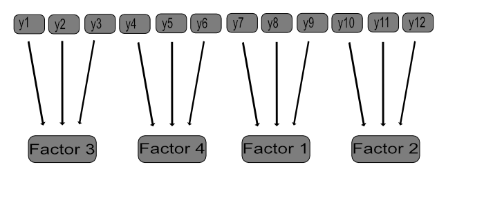

## Week 2

#### Exercise 2.1

The null hypothesis is that self-concept (SC) is a multidimensional construct composed of four factors:

- General SC (GSC)
- Academic SC (ASC)
- English SC (ESC)
- Mathematics SC (MSC)

Alternative hypothesis is that self-concept is not a multidimensional construct composed of four factors.

Let us bring the data in R and prepare it for analysis:

Then let us specify the model, visualize the model structure:

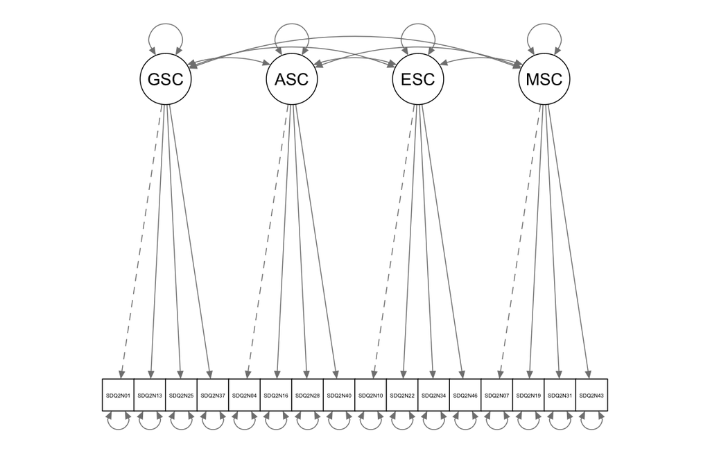

```
## lavaan 0.6-3 ended normally after 49 iterations
##
##   Optimization method                           NLMINB
##   Number of free parameters                         38
##
##   Number of observations                           265
##
##   Estimator                                         ML
##   Model Fit Test Statistic                     159.112
##   Degrees of freedom                                98
##   P-value (Chi-square)                           0.000
##
## Model test baseline model:
##
##   Minimum Function Test Statistic             1703.155
##   Degrees of freedom                               120
##   P-value                                        0.000
##
## User model versus baseline model:
##
##   Comparative Fit Index (CFI)                    0.961
##   Tucker-Lewis Index (TLI)                       0.953
##
## Loglikelihood and Information Criteria:
##
##   Loglikelihood user model (H0)              -6562.678
##   Loglikelihood unrestricted model (H1)      -6483.122
##
##   Number of free parameters                         38
##   Akaike (AIC)                               13201.356
##   Bayesian (BIC)                             13337.386
##   Sample-size adjusted Bayesian (BIC)        13216.905
##
## Root Mean Square Error of Approximation:
##
##   RMSEA                                          0.049
##   90 Percent Confidence Interval          0.034  0.062
##   P-value RMSEA <= 0.05                          0.556
##
## Standardized Root Mean Square Residual:
```

[output cut: 51 more lines]

```
##    .SDQ2N16           0.616    0.068    9.020    0.000
##    .SDQ2N28           0.896    0.090    9.959    0.000
##    .SDQ2N40           0.952    0.095   10.029    0.000
##    .SDQ2N10           0.653    0.082    7.941    0.000
##    .SDQ2N22           0.657    0.075    8.735    0.000
##    .SDQ2N34           2.590    0.233   11.128    0.000
##    .SDQ2N46           1.201    0.118   10.183    0.000
##    .SDQ2N07           0.854    0.100    8.551    0.000
##    .SDQ2N19           1.228    0.121   10.153    0.000
##    .SDQ2N31           0.365    0.065    5.649    0.000
##    .SDQ2N43           0.964    0.092   10.473    0.000
##     GSC               0.613    0.137    4.464    0.000
##     ASC               0.561    0.126    4.453    0.000
##     ESC               0.668    0.116    5.749    0.000
##     MSC               2.307    0.273    8.460    0.000
```

The hypothesis that SC has four factors is not supported by the results (chi square statistic = 159.112, p = 0.000), which suggest that the fit of the data to the model is not adequate and null hypothesis should be rejected. However, the indices CFI (0.961), TLI (0.953) and RMSEA (0.049) support the null hypothesis.

#### Exercise 2.2

##### a) Hypothesis 2:

The null hypothesis is that SC has two factors:

- General SC (GSC)
- Academic SC (ASC)

Alternative hypothesis is that SC does not have two factors. Let us form the model and visualize the model structure:

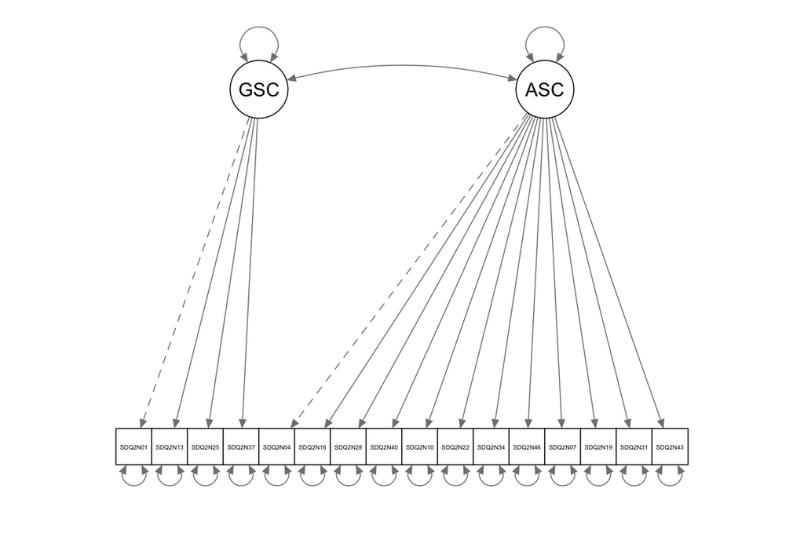

```
## lavaan 0.6-3 ended normally after 38 iterations
##
##   Optimization method                           NLMINB
##   Number of free parameters                         33
##
##   Number of observations                           265
##
##   Estimator                                         ML
##   Model Fit Test Statistic                     457.653
##   Degrees of freedom                               103
##   P-value (Chi-square)                           0.000
##
## Model test baseline model:
##
##   Minimum Function Test Statistic             1703.155
##   Degrees of freedom                               120
##   P-value                                        0.000
##
## User model versus baseline model:
##
##   Comparative Fit Index (CFI)                    0.776
##   Tucker-Lewis Index (TLI)                       0.739
##
## Loglikelihood and Information Criteria:
##
##   Loglikelihood user model (H0)              -6711.949
##   Loglikelihood unrestricted model (H1)      -6483.122
##
##   Number of free parameters                         33
##   Akaike (AIC)                               13489.897
##   Bayesian (BIC)                             13608.028
##   Sample-size adjusted Bayesian (BIC)        13503.401
##
## Root Mean Square Error of Approximation:
##
##   RMSEA                                          0.114
##   90 Percent Confidence Interval          0.103  0.125
##   P-value RMSEA <= 0.05                          0.000
##
## Standardized Root Mean Square Residual:
```

[output cut: 40 more lines]

```
##    .SDQ2N37           0.799    0.090    8.842    0.000
##    .SDQ2N04           1.495    0.134   11.171    0.000
##    .SDQ2N16           0.799    0.076   10.490    0.000
##    .SDQ2N28           1.018    0.095   10.695    0.000
##    .SDQ2N40           1.138    0.105   10.828    0.000
##    .SDQ2N10           1.166    0.103   11.364    0.000
##    .SDQ2N22           1.043    0.092   11.360    0.000
##    .SDQ2N34           2.888    0.251   11.510    0.000
##    .SDQ2N46           1.554    0.136   11.425    0.000
##    .SDQ2N07           1.191    0.123    9.654    0.000
##    .SDQ2N19           1.247    0.124   10.067    0.000
##    .SDQ2N31           0.575    0.073    7.852    0.000
##    .SDQ2N43           0.996    0.095   10.442    0.000
##     GSC               0.641    0.142    4.508    0.000
##     ASC               0.461    0.114    4.034    0.000
```

##### b) Hypothesis 3:

The null hypothesis is that SC is unidimensional (only one SC factor).

Alternative hypothesis is that SC is not unidimensional. Let us form the model and visualize the model structure:

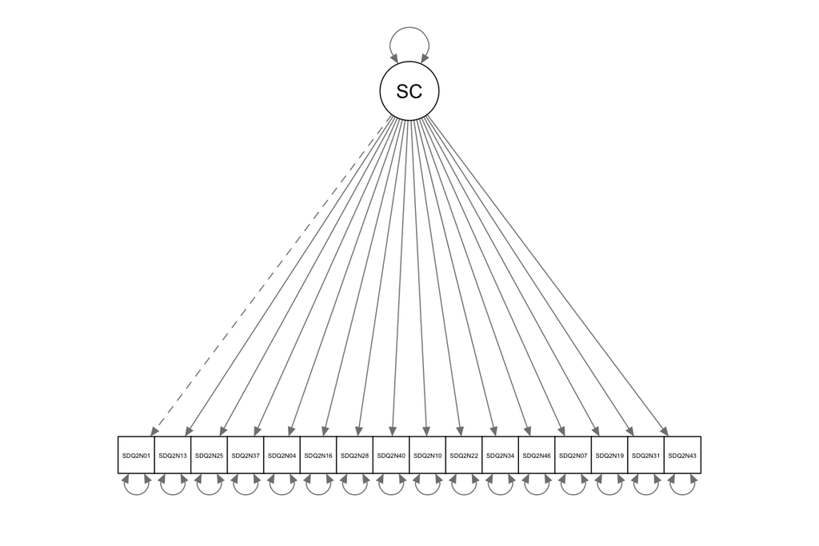

```
## lavaan 0.6-3 ended normally after 43 iterations
##
##   Optimization method                           NLMINB
##   Number of free parameters                         32
##
##   Number of observations                           265
##
##   Estimator                                         ML
##   Model Fit Test Statistic                     531.918
##   Degrees of freedom                               104
##   P-value (Chi-square)                           0.000
##
## Model test baseline model:
##
##   Minimum Function Test Statistic             1703.155
##   Degrees of freedom                               120
##   P-value                                        0.000
##
## User model versus baseline model:
##
##   Comparative Fit Index (CFI)                    0.730
##   Tucker-Lewis Index (TLI)                       0.688
##
## Loglikelihood and Information Criteria:
##
##   Loglikelihood user model (H0)              -6749.081
##   Loglikelihood unrestricted model (H1)      -6483.122
##
##   Number of free parameters                         32
##   Akaike (AIC)                               13562.162
##   Bayesian (BIC)                             13676.713
##   Sample-size adjusted Bayesian (BIC)        13575.256
##
## Root Mean Square Error of Approximation:
##
##   RMSEA                                          0.125
##   90 Percent Confidence Interval          0.114  0.135
##   P-value RMSEA <= 0.05                          0.000
##
## Standardized Root Mean Square Residual:
```

[output cut: 33 more lines]

```
##    .SDQ2N25           1.299    0.115   11.338    0.000
##    .SDQ2N37           0.994    0.089   11.160    0.000
##    .SDQ2N04           1.469    0.132   11.140    0.000
##    .SDQ2N16           0.762    0.073   10.368    0.000
##    .SDQ2N28           0.994    0.093   10.633    0.000
##    .SDQ2N40           1.093    0.102   10.742    0.000
##    .SDQ2N10           1.140    0.101   11.333    0.000
##    .SDQ2N22           1.022    0.090   11.332    0.000
##    .SDQ2N34           2.882    0.250   11.508    0.000
##    .SDQ2N46           1.535    0.135   11.409    0.000
##    .SDQ2N07           1.311    0.132    9.913    0.000
##    .SDQ2N19           1.316    0.129   10.186    0.000
##    .SDQ2N31           0.650    0.078    8.367    0.000
##    .SDQ2N43           1.040    0.099   10.520    0.000
##     SC                0.246    0.083    2.972    0.003
```

The hypothesis that SC is unidimensional is not supported by the results (chi square statistic = 531.918, p = 0.000), which suggest that the fit of the data to the model is not adequate and null hypothesis should be rejected. In addition the indices CFI (0.730), TLI (0.688) and RMSEA (0.125) are not supporting the null hypothesis.

Overall the best fit of these three models is the first one with four factors since it is the only model that had at least some support for the model fit.

## Week 3

#### Exercise 3.1

The null hypothesis is that burnout is a multidimensional construct composed of three factors:

- Emotional Exhaustion (EE)
- Depersonalization (DP)
- Personal Accomplishment (PA)

Alternative hypothesis is that burnout is not a multidimensional construct composed of three factors.

Let us bring the data in R and prepare it for analysis:

Then let us do some EDA to see whether the items are normally distributed:

```
##        vars   n mean   sd median trimmed  mad min max range  skew kurtosis
## ITEM1     1 372 4.37 1.66    4.0    4.36 2.97   1   7     6 -0.11    -1.17
## ITEM2     2 372 4.87 1.55    5.0    4.97 1.48   1   7     6 -0.50    -0.71
## ITEM3     3 372 3.53 1.73    3.0    3.49 1.48   1   7     6  0.32    -1.11
## ITEM4     4 372 6.30 1.00    7.0    6.50 0.00   2   7     5 -1.80     3.63
## ITEM5     5 372 2.20 1.49    2.0    1.92 1.48   1   7     6  1.32     0.91
## ITEM6     6 372 2.71 1.58    2.0    2.50 1.48   1   7     6  0.92    -0.01
## ITEM7     7 372 6.31 0.84    6.0    6.46 1.48   2   7     5 -1.64     3.77
## ITEM8     8 372 3.04 1.73    2.0    2.89 1.48   1   7     6  0.74    -0.61
## ITEM9     9 372 6.03 1.32    7.0    6.29 0.00   1   7     6 -1.54     1.84
## ITEM10   10 372 2.20 1.45    2.0    1.96 1.48   1   7     6  1.20     0.56
## ITEM11   11 372 2.24 1.53    2.0    1.97 1.48   1   7     6  1.27     0.80
## ITEM12   12 372 5.70 1.19    6.0    5.86 1.48   1   7     6 -1.31     1.84
## ITEM13   13 372 3.59 1.68    3.5    3.52 2.22   1   7     6  0.35    -0.79
## ITEM14   14 372 4.03 1.73    4.0    4.01 1.48   1   7     6  0.03    -0.94
## ITEM15   15 372 1.77 1.30    1.0    1.47 0.00   1   7     6  2.09     4.24
## ITEM16   16 372 2.47 1.44    2.0    2.28 1.48   1   7     6  0.97     0.16
## ITEM17   17 372 6.41 0.85    7.0    6.58 0.00   2   7     5 -1.97     5.06
## ITEM18   18 372 5.70 1.27    6.0    5.87 1.48   1   7     6 -1.23     1.34
## ITEM19   19 372 5.95 1.19    6.0    6.15 1.48   1   7     6 -1.48     2.21
## ITEM20   20 372 2.24 1.41    2.0    2.01 1.48   1   7     6  1.29     1.17
## ITEM21   21 372 5.85 1.27    6.0    6.06 1.48   2   7     5 -1.29     1.16
## ITEM22   22 372 2.58 1.58    2.0    2.35 1.48   1   7     6  1.06     0.18
##          se
## ITEM1  0.09
## ITEM2  0.08
## ITEM3  0.09
## ITEM4  0.05
## ITEM5  0.08
## ITEM6  0.08
## ITEM7  0.04
## ITEM8  0.09
## ITEM9  0.07
## ITEM10 0.08
## ITEM11 0.08
## ITEM12 0.06
## ITEM13 0.09
## ITEM14 0.09
## ITEM15 0.07
## ITEM16 0.07
## ITEM17 0.04
## ITEM18 0.07
## ITEM19 0.06
## ITEM20 0.07
## ITEM21 0.07
## ITEM22 0.08
```

The skewness and kurtosis values for basicly all the items indicate that none of the items are normally distributed and therefore the maximum likelihood estimators are not suited for the task. Let us visualize the distributions of the items:

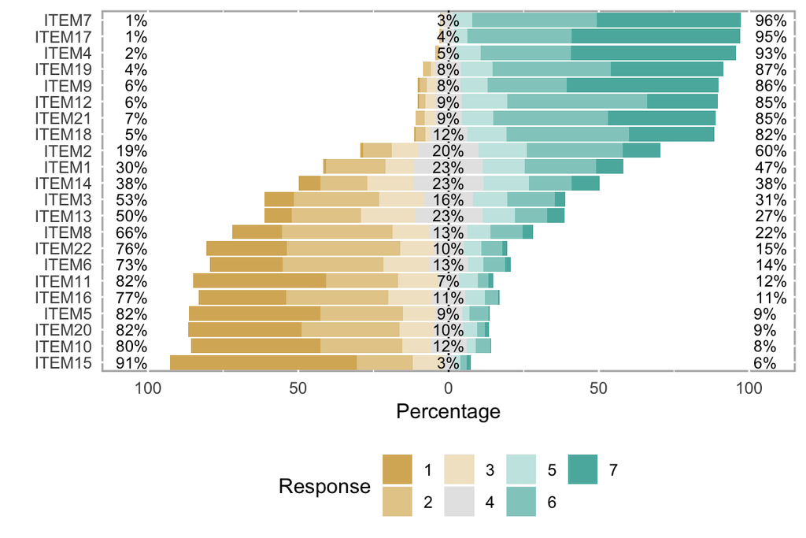

The visualization also shows that the items are not normally distributed.

#### ML estimator

Then let us specify the model according to instructions and visualize the model structure using ML estimator:

```
## lavaan 0.6-3 ended normally after 46 iterations
##
##   Optimization method                           NLMINB
##   Number of free parameters                         47
##
##   Number of observations                           372
##
##   Estimator                                         ML
##   Model Fit Test Statistic                     695.719
##   Degrees of freedom                               206
##   P-value (Chi-square)                           0.000
##
## Model test baseline model:
##
##   Minimum Function Test Statistic             3452.269
##   Degrees of freedom                               231
##   P-value                                        0.000
##
## User model versus baseline model:
##
##   Comparative Fit Index (CFI)                    0.848
##   Tucker-Lewis Index (TLI)                       0.830
##
## Loglikelihood and Information Criteria:
##
##   Loglikelihood user model (H0)             -12811.043
##   Loglikelihood unrestricted model (H1)     -12463.184
##
##   Number of free parameters                         47
##   Akaike (AIC)                               25716.087
##   Bayesian (BIC)                             25900.275
##   Sample-size adjusted Bayesian (BIC)        25751.158
##
## Root Mean Square Error of Approximation:
##
##   RMSEA                                          0.080
##   90 Percent Confidence Interval          0.073  0.087
##   P-value RMSEA <= 0.05                          0.000
##
## Standardized Root Mean Square Residual:
```

[output cut: 57 more lines]

```
##    .ITEM10            1.169    0.107   10.901    0.000
##    .ITEM11            1.044    0.112    9.330    0.000
##    .ITEM15            1.106    0.093   11.838    0.000
##    .ITEM22            2.076    0.160   12.958    0.000
##    .ITEM4             0.802    0.062   12.901    0.000
##    .ITEM7             0.523    0.042   12.572    0.000
##    .ITEM9             1.117    0.093   11.952    0.000
##    .ITEM12            0.987    0.080   12.287    0.000
##    .ITEM17            0.375    0.035   10.739    0.000
##    .ITEM18            0.909    0.081   11.224    0.000
##    .ITEM19            0.844    0.073   11.557    0.000
##    .ITEM21            1.245    0.098   12.764    0.000
##     EE                1.625    0.190    8.551    0.000
##     DP                0.705    0.132    5.321    0.000
##     PA                0.193    0.048    4.047    0.000
```

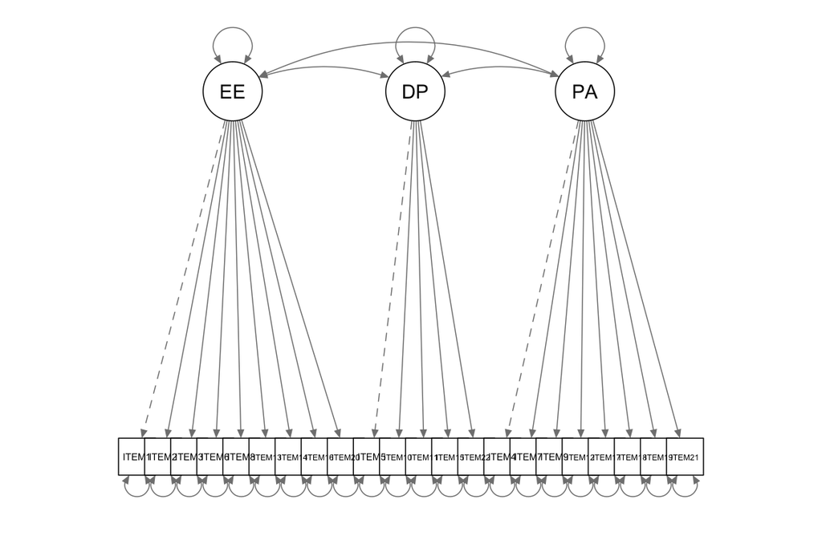

The hypothesis that burnout has three factors is not supported by the results (chi square statistic = 695.719, p = 0.000), which suggest that the fit of the data to the model is not adequate and null hypothesis should be rejected. Also the indices CFI (0.848), TLI (0.83) support against hypothesis. However, RMSEA (0.08) modestly supports the null hypothesis.

#### MLM estimator

Then let us test the model fit with MLM estimator:

```
## lavaan 0.6-3 ended normally after 46 iterations
##
##   Optimization method                           NLMINB
##   Number of free parameters                         47
##
##   Number of observations                           372
##
##   Estimator                                         ML      Robust
##   Model Fit Test Statistic                     695.719     567.753
##   Degrees of freedom                               206         206
##   P-value (Chi-square)                           0.000       0.000
##   Scaling correction factor                                  1.225
##     for the Satorra-Bentler correction
##
## Model test baseline model:
##
##   Minimum Function Test Statistic             3452.269    2911.466
##   Degrees of freedom                               231         231
##   P-value                                        0.000       0.000
##
## User model versus baseline model:
##
##   Comparative Fit Index (CFI)                    0.848       0.865
##   Tucker-Lewis Index (TLI)                       0.830       0.849
##
##   Robust Comparative Fit Index (CFI)                         0.861
##   Robust Tucker-Lewis Index (TLI)                            0.844
##
## Loglikelihood and Information Criteria:
##
##   Loglikelihood user model (H0)             -12811.043  -12811.043
##   Loglikelihood unrestricted model (H1)     -12463.184  -12463.184
##
##   Number of free parameters                         47          47
##   Akaike (AIC)                               25716.087   25716.087
##   Bayesian (BIC)                             25900.275   25900.275
##   Sample-size adjusted Bayesian (BIC)        25751.158   25751.158
##
## Root Mean Square Error of Approximation:
##
```

[output cut: 65 more lines]

```
##    .ITEM10            1.169    0.147    7.959    0.000
##    .ITEM11            1.044    0.141    7.398    0.000
##    .ITEM15            1.106    0.153    7.220    0.000
##    .ITEM22            2.076    0.184   11.266    0.000
##    .ITEM4             0.802    0.113    7.124    0.000
##    .ITEM7             0.523    0.075    7.010    0.000
##    .ITEM9             1.117    0.149    7.487    0.000
##    .ITEM12            0.987    0.126    7.852    0.000
##    .ITEM17            0.375    0.056    6.635    0.000
##    .ITEM18            0.909    0.143    6.376    0.000
##    .ITEM19            0.844    0.111    7.622    0.000
##    .ITEM21            1.245    0.133    9.338    0.000
##     EE                1.625    0.148   11.004    0.000
##     DP                0.705    0.158    4.452    0.000
##     PA                0.193    0.050    3.839    0.000
```

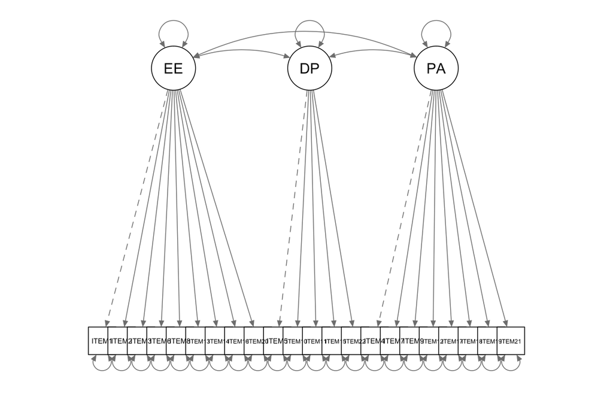

With this estimator the hypothesis that burnout has three factors is also not supported by the results (chi square statistic = 567.753, p = 0.000), which suggest that the fit of the data to the model is not adequate and null hypothesis should be rejected. Here the indices increase small amounts CFI (0.865), TLI (0.849) and RMSEA decreases small amount (0.076) but still these indices support against hypothesis.

## Week 4

### Exercise 4.1

Let us import the data file in R, prepare the data and build the model according to the input file. Then let us draw the graph of the initial, full structural equation model.

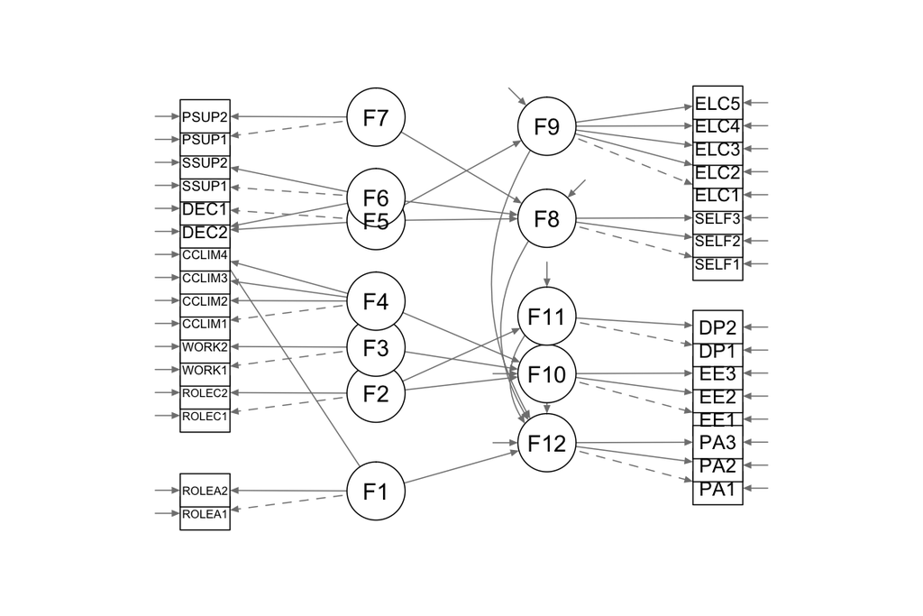

Then let us estimate the initial model using the robust MLM estimator and present a brief summary of the model fit:

```
##         chisq.scaled            df.scaled        pvalue.scaled
##             1541.844              427.000                0.000
## chisq.scaling.factor           cfi.robust           tli.robust
##                1.127                0.945                0.936
##         rmsea.robust
##                0.045
```

In the output Chi square statistic 1541.844 (df = 427, p = 0.000) suggests against a good fit. However the fit indices robust CFI (0.945), robust TLI (0.936) and robust RMSEA (0.045) indicate good fit.

### Exercise 4.2

Then let us print the modification indices (MI) for the model:

```
##      lhs op rhs      mi    epc sepc.lv sepc.all sepc.nox
## 1038 F11  ~  F4 112.597 -0.974  -0.339   -0.339   -0.339
## 1104  F4  ~ F11  90.818 -0.141  -0.404   -0.404   -0.404
## 1037 F11  ~  F3  85.322 -4.799  -4.467   -4.467   -4.467
```

#### Model 2

F11 ~ F4 has the highest MI value. Following the lecture material we specify another model by adding F11 ~ F4:

```
##         chisq.scaled            df.scaled        pvalue.scaled
##             1440.864              426.000                0.000
## chisq.scaling.factor           cfi.robust           tli.robust
##                1.125                0.950                0.942
##         rmsea.robust
##                0.043
```

Let us list the indices from two first models so they can be compared:

```
##    ChiSquare  DF p ChiSq.sc.factor   CFI   TLI RMSEA
## M1  1541.844 427 0           1.127 0.945 0.936 0.045
## M2  1440.864 426 0           1.125 0.950 0.942 0.043
```

The model 2 seems to have better fit than the original model: Chi square statistic is still significant 1440.864 (df = 426, p = 0.000) and suggests against a good fit. However the fit indices robust CFI (0.95), robust TLI (0.942) and robust RMSEA (0.043) all indicate slightly better fit than original model.

Then let us calculate the Chi-Square Difference Test:

```
## [1] 58.9622
```

```
## Scaled Chi Square Difference Test (method = "satorra.bentler.2001")
##
##       Df   AIC   BIC  Chisq Chisq diff Df diff Pr(>Chisq)
## fit2 426 94568 95105 1620.4
## fit  427 94682 95214 1737.1      58.82       1  1.728e-14 ***
## ---
## Signif. codes:  0 '***' 0.001 '**' 0.01 '*' 0.05 '.' 0.1 ' ' 1
```

Both tests show almost exactly the same results and indicate significant difference between models.

#### Model 3

Next, we specify a third model by adding F12 ~ F5:

```
##         chisq.scaled            df.scaled        pvalue.scaled
##             1396.527              425.000                0.000
## chisq.scaling.factor           cfi.robust           tli.robust
##                1.125                0.952                0.944
##         rmsea.robust
##                0.042
```

```
##    ChiSquare  DF p ChiSq.sc.factor   CFI   TLI RMSEA
## M1  1541.844 427 0           1.127 0.945 0.936 0.045
## M2  1440.864 426 0           1.125 0.950 0.942 0.043
## M3  1396.527 425 0           1.125 0.952 0.944 0.042
```

The third model seems to improve the fit from the 2nd model slightly in the same manner as the second model improved the original model.

```
## [1] 44.337
```

The Chi-Square Difference Test indicates that the difference between models is significant.

#### Model 4

Next, we specify a fourth model by adding F9 ~ F2:

```
##         chisq.scaled            df.scaled        pvalue.scaled
##             1356.810              424.000                0.000
## chisq.scaling.factor           cfi.robust           tli.robust
##                1.125                0.954                0.946
##         rmsea.robust
##                0.042
```

```
##    ChiSquare  DF p ChiSq.sc.factor   CFI   TLI RMSEA
## M1  1541.844 427 0           1.127 0.945 0.936 0.045
## M2  1440.864 426 0           1.125 0.950 0.942 0.043
## M3  1396.527 425 0           1.125 0.952 0.944 0.042
## M4  1356.810 424 0           1.125 0.954 0.946 0.042
```

The fourth model seems to improve the fit from the third model slightly in the same manner as the third model improved the second model.

#### Model 5

Next, we specify a fifth model by adding F9 ~ F8:

```
##    ChiSquare  DF p ChiSq.sc.factor   CFI   TLI RMSEA
## M1  1541.844 427 0           1.127 0.945 0.936 0.045
## M2  1440.864 426 0           1.125 0.950 0.942 0.043
## M3  1396.527 425 0           1.125 0.952 0.944 0.042
## M4  1356.810 424 0           1.125 0.954 0.946 0.042
## M5  1323.061 423 0           1.124 0.956 0.948 0.041
```

The fifth model seems to improve the fit from the fourth model slightly in the same manner as the fourth model improved the third model.

#### Model 6

Next, we specify a sixth model by adding F10 ~ F8:

```
##    ChiSquare  DF p ChiSq.sc.factor   CFI   TLI RMSEA
## M1  1541.844 427 0           1.127 0.945 0.936 0.045
## M2  1440.864 426 0           1.125 0.950 0.942 0.043
## M3  1396.527 425 0           1.125 0.952 0.944 0.042
## M4  1356.810 424 0           1.125 0.954 0.946 0.042
## M5  1323.061 423 0           1.124 0.956 0.948 0.041
## M6  1288.246 422 0           1.124 0.958 0.950 0.040
```

The sixth model seems to improve the fit from the fifth model slightly in the same manner as the fifth model improved the fourth model.

#### Model 7

Next, we specify a seventh model by adding F12 ~ F2:

```
##    ChiSquare  DF p ChiSq.sc.factor   CFI   TLI RMSEA
## M1  1541.844 427 0           1.127 0.945 0.936 0.045
## M2  1440.864 426 0           1.125 0.950 0.942 0.043
## M3  1396.527 425 0           1.125 0.952 0.944 0.042
## M4  1356.810 424 0           1.125 0.954 0.946 0.042
## M5  1323.061 423 0           1.124 0.956 0.948 0.041
## M6  1288.246 422 0           1.124 0.958 0.950 0.040
## M7  1267.581 421 0           1.124 0.958 0.951 0.040
```

The seventh model seems to improve the fit from the sixth model slightly in the same manner as the sixth model improved the fifth model.

#### Model 8

The final model 8 is specified by removing F8 ~ F7 and F12 ~ F1:

```
##    ChiSquare  DF p ChiSq.sc.factor   CFI   TLI RMSEA
## M1  1541.844 427 0           1.127 0.945 0.936 0.045
## M2  1440.864 426 0           1.125 0.950 0.942 0.043
## M3  1396.527 425 0           1.125 0.952 0.944 0.042
## M4  1356.810 424 0           1.125 0.954 0.946 0.042
## M5  1323.061 423 0           1.124 0.956 0.948 0.041
## M6  1288.246 422 0           1.124 0.958 0.950 0.040
## M7  1267.581 421 0           1.124 0.958 0.951 0.040
## M8  1275.427 423 0           1.123 0.958 0.951 0.040
```

The final model seems to not improve the fit from the seventh model. All in all all the steps have improved the fit nicely: the Chi Square statistic decreased from 1541.844 to 1275.427, CFI increased from 0.945 to 0.958, TLI increased from 0.936 to 0.951 and RMSEA decreased from 0.045 to 0.040.

### Exercise 4.3

Let us draw the graphs of the original and the final models:

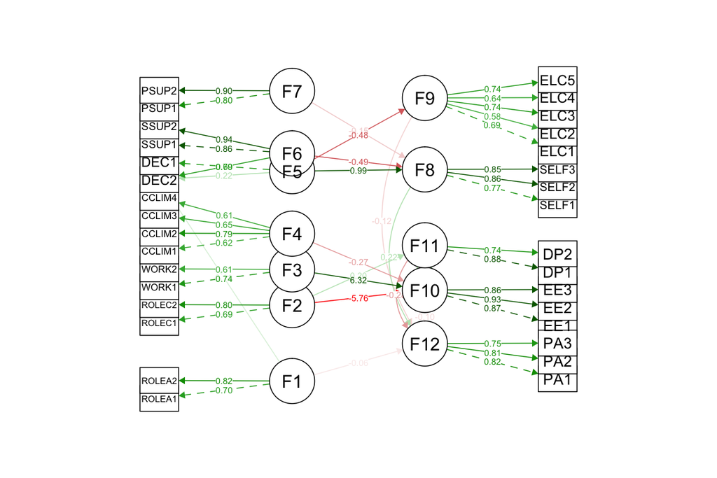

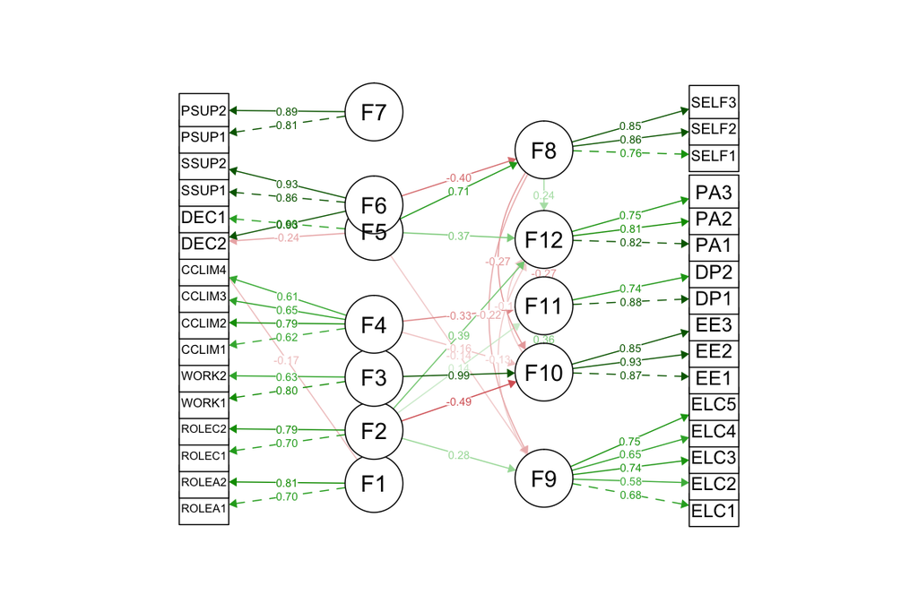

## Week 5

### Exercise 5.1

The subject of this exercise are the relations among the three dimensions of burnout and their invariance across elementary and secondary teachers. The data files consist of elementary (N=580) and secondary (N=692) teachers with 22 MBI items. The aim is to test the invariance of MBI across the samples.

Let us import the data file in R, prepare the data and build the model according to the input file.

Fit indices (Model 1)

| Group | Chi.square | df | p.value | Scaling.correction.factor | CFI | TLI | RMSEA | SRMR |
| --- | --- | --- | --- | --- | --- | --- | --- | --- |
| Elementary | 802.7431 | 206 | 0 | 1.261 | 0.858 | 0.841 | 0.079 | 0.071 |
| Secondary | 971.0638 | 206 | 0 | 1.321 | 0.835 | 0.815 | 0.084 | 0.080 |

The fit indices of the initial models are shown in table 1. The scaling correction factor indices (1.261 and 1.321) support the use of MLM robust estimators. All fit indices imply poor fit of both models (p < 0.001 [df=206], CFI < 0.9, TLI <0.9, RMSEA > 0.05). Let us continue to model modification.

### Modification indices

```
##        lhs op    rhs      mi    epc sepc.lv sepc.all sepc.nox
## 158  ITEM6 ~~ ITEM16 180.298  0.893   0.893    0.595    0.595
## 95   ITEM1 ~~  ITEM2 103.177  0.534   0.534    0.494    0.494
## 59      EE =~ ITEM12  81.319 -0.400  -0.515   -0.400   -0.400
## 260 ITEM10 ~~ ITEM11  67.743  0.688   0.688    0.832    0.832
## 323 ITEM18 ~~ ITEM19  43.669  0.279   0.279    0.340    0.340
## 298  ITEM4 ~~  ITEM7  42.833  0.184   0.184    0.294    0.294
```

```
##        lhs op    rhs      mi    epc sepc.lv sepc.all sepc.nox
## 95   ITEM1 ~~  ITEM2 171.647  0.627   0.627    0.583    0.583
## 260 ITEM10 ~~ ITEM11 135.841  1.181   1.181    1.426    1.426
## 158  ITEM6 ~~ ITEM16 127.756  0.686   0.686    0.458    0.458
## 59      EE =~ ITEM12 118.156 -0.468  -0.561   -0.419   -0.419
## 250  ITEM5 ~~ ITEM15  77.216  0.580   0.580    0.355    0.355
## 271 ITEM11 ~~ ITEM15  60.947 -0.485  -0.485   -0.420   -0.420
## 122  ITEM2 ~~ ITEM20  53.024 -0.324  -0.324   -0.316   -0.316
## 249  ITEM5 ~~ ITEM11  48.297 -0.446  -0.446   -0.369   -0.369
## 314  ITEM9 ~~ ITEM19  46.617  0.360   0.360    0.358    0.358
## 52      EE =~ ITEM10  45.623 -0.394  -0.473   -0.302   -0.302
```

The results (modification indices MI and expected parameter change EPC) suggest that we should add ITEM6 ~~ ITEM16, ITEM1 ~~ ITEM2 and ITEM10 ~~ ITEM1. Also a cross-loading of item 12 on factor F1 (EE) is implied. These results are shared in both groups. Let us modify the model:

### Model 2

Fit indices (Model 2)

| Group | Chi.square | df | p.value | Scaling.correction.factor | CFI | TLI | RMSEA | SRMR |
| --- | --- | --- | --- | --- | --- | --- | --- | --- |
| Elementary | 470.3767 | 202 | 0 | 1.243 | 0.937 | 0.928 | 0.053 | 0.053 |
| Secondary | 572.5523 | 202 | 0 | 1.311 | 0.921 | 0.909 | 0.059 | 0.058 |

The indices improved quite a lot for both models, but we need to continue modifying the model:

### Modification indices

```
##        lhs op    rhs     mi   epc sepc.lv sepc.all sepc.nox
## 305  ITEM4 ~~  ITEM7 38.931 0.174   0.174    0.284    0.284
## 323 ITEM18 ~~ ITEM19 38.744 0.266   0.266    0.333    0.333
```

```
##       lhs op    rhs     mi   epc sepc.lv sepc.all sepc.nox
## 57     EE =~ ITEM11 67.177 0.472   0.532    0.339    0.339
## 318 ITEM9 ~~ ITEM19 43.690 0.355   0.355    0.357    0.357
## 263 ITEM5 ~~ ITEM15 35.576 0.416   0.416    0.310    0.310
```

In the group of elementary teachers, items 4 and 7 have the highest values for the residual covariance. The group of secondary teachers has the highest MI value for the cross-loading of item 11 on F1. We must specify model 3 separately for these groups according to these findings.

### Model 3

Fit indices (Model 3)

| Group | Chi.square | df | p.value | Scaling.correction.factor | CFI | TLI | RMSEA | SRMR |
| --- | --- | --- | --- | --- | --- | --- | --- | --- |
| Elementary | 445.8005 | 201 | 0 | 1.224 | 0.944 | 0.935 | 0.051 | 0.051 |
| Secondary | 522.9823 | 201 | 0 | 1.307 | 0.931 | 0.921 | 0.055 | 0.055 |

### Modification indices

```
##        lhs op    rhs     mi   epc sepc.lv sepc.all sepc.nox
## 323 ITEM18 ~~ ITEM19 32.503 0.247   0.247    0.319    0.319
```

```
##       lhs op    rhs     mi   epc sepc.lv sepc.all sepc.nox
## 318 ITEM9 ~~ ITEM19 42.687 0.351   0.351    0.355    0.355
```

The MI and EPC values imply that continuing modification is not needed for the elementary teachers group. According to MI and EPC values the model for secondary teachers group can be fine tuned further by allowing residual covariance of items 9 and 19. Model 4 will be done separately for secondary teachers group only.

### Model 4

Fit indices (Model 4)

|  | Group | Chi.square | df | p.value | Scaling.correction.factor | CFI | TLI | RMSEA | SRMR |
| --- | --- | --- | --- | --- | --- | --- | --- | --- | --- |
| chisq.scaled | Secondary | 492.2819 | 200 | 0 | 1.308 | 0.938 | 0.928 | 0.053 | 0.054 |

Now we have achieved baseline models for both teacher groups. Let us print their fit indices:

Fit indices (Baseline models)

| Group | Chi.square | df | p.value | Scaling.correction.factor | CFI | TLI | RMSEA | SRMR |
| --- | --- | --- | --- | --- | --- | --- | --- | --- |
| Elementary | 445.8005 | 201 | 0 | 1.224 | 0.944 | 0.935 | 0.051 | 0.051 |
| Secondary | 492.2819 | 200 | 0 | 1.308 | 0.938 | 0.928 | 0.053 | 0.054 |

### Exercise 5.2

Let us combine the groups and specify the common baseline (configural) model and draw the graphs.

```
##         chisq.scaled            df.scaled        pvalue.scaled
##              958.341              401.000                0.000
## chisq.scaling.factor           cfi.robust           tli.robust
##                1.242                0.940                0.930
##         rmsea.robust
##                0.052
```

Graphs of the common baseline model (configural model) are presented below. The first graph is for the elementary school teachers and the second graph is for the secondary school teachers.

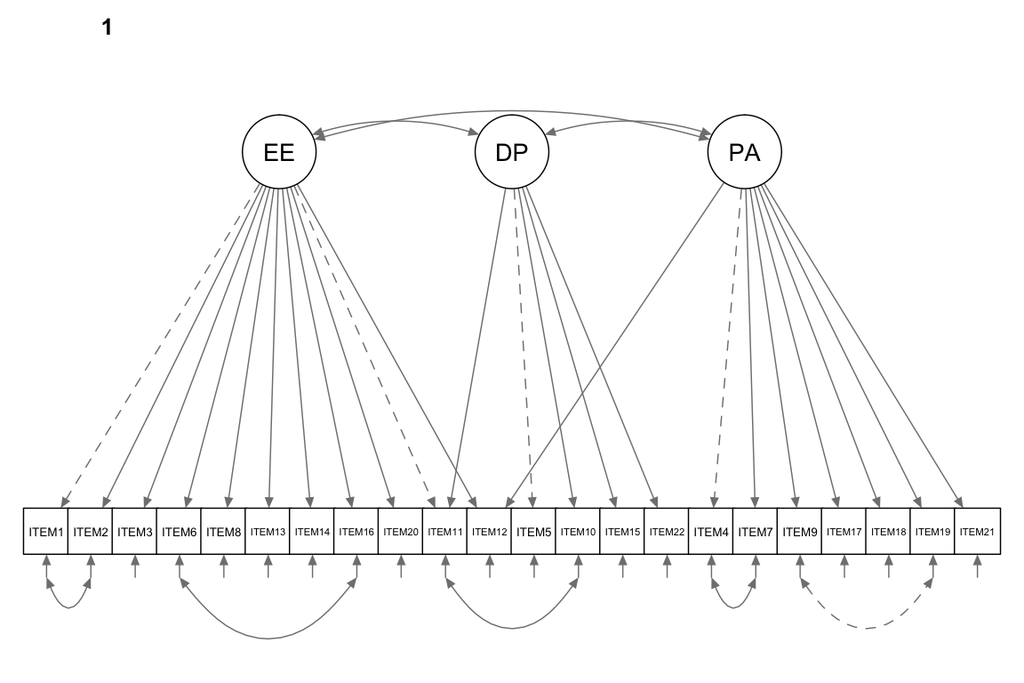

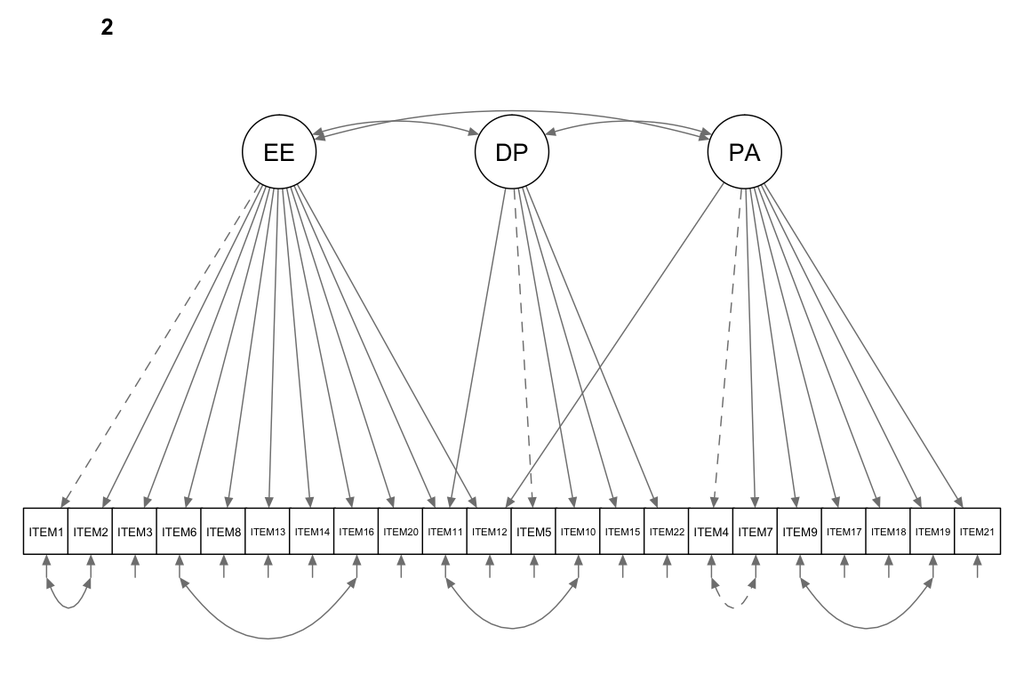

## Week 6

First let us import the data file in R and prepare it for the excercises.

### Exercise 6.1

Let us specify and establish a well-fitting and parsimonious baseline model for the calibration group. We begin with the hypothesized model:

### Hypothesized model:

```r
model <- '
RA  =~ ROLEA1 + ROLEA2
RC  =~ ROLEC1 + ROLEC2
WO  =~ WORK1 + WORK2
CC  =~ CCLIM1 + CCLIM2 + CCLIM3 + CCLIM4
DM  =~ DEC1 + DEC2
SS  =~ SSUP1 + SSUP2
PS  =~ PSUP1 + PSUP2
SE  =~ SELF1 + SELF2 + SELF3
ELC  =~ ELC1 + ELC2 + ELC3 + ELC4 + ELC5
EE  =~ EE1 + EE2 + EE3
DP  =~ DP1 + DP2
PA  =~ PA1 + PA2 + PA3

SE ~ DM + SS + PS
ELC ~ DM
EE ~ RC + WO + CC
DP ~ RC + EE
PA ~ RA + SE + ELC + EE + DP
'

fit <- sem(model, data = E1, estimator="MLM")
```

First we draw the hypothesized model in Figure 1.

The factor names are as follows:

- RA = Role ambiguity
- RC = Role conflict
- WO = Work overload
- CC = Classroom climate
- DM = Decision-making
- SS = Superior support
- PS = Peer support
- SE = Self-esteem
- ELC = External locus of control
- EE = Emotional exhaustion
- DP = Depersonalization
- PA = Personal accomplishment

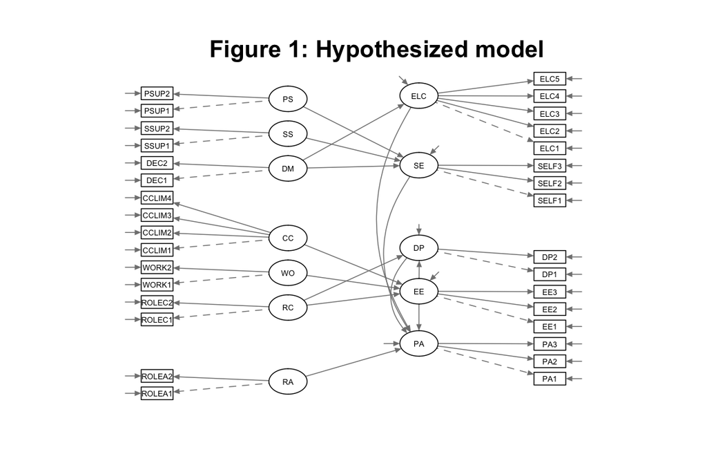

Let us view the standardized covariance estimates exceeding the value of 1:

Covariance estimates of the initial model that exceed 1

| Item/Factor | op | Item/Factor | Est.covariance | Std.covariance | pvalue |
| --- | --- | --- | --- | --- | --- |
| EE | ~~ | EE | 3.457 | 2.371 | 0.533 |
| RC | ~~ | WO | 0.674 | 1.005 | 0.000 |

Table 1 shows that the standardized covariance of factors RC and WO is 1.005, which means the factors are representing the same construct. Therefore we can combine them. Let us specify a new model and view a graph of the model:

### Modified model:

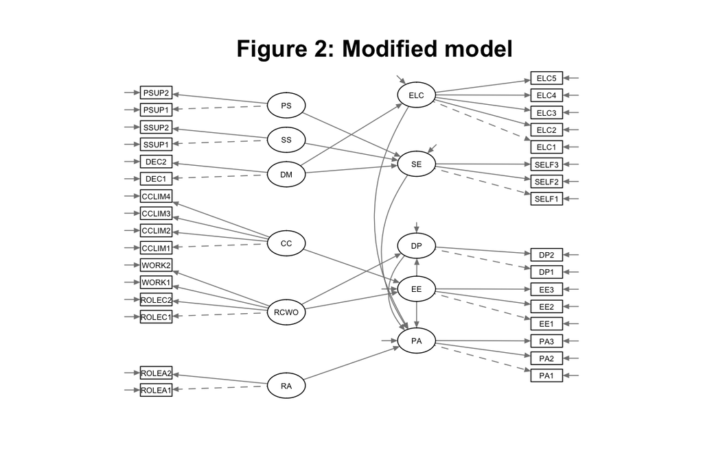

Let us view the fit measures of the modified model:

Fit indices (Modified model)

| Model | Chi.square | Df | p.value | CFI | TLI | RMSEA | SRMR |
| --- | --- | --- | --- | --- | --- | --- | --- |
| Modified | 942.1924 | 436 | 0 | 0.944 | 0.936 | 0.046 | 0.062 |

The fit indices indicate that the fit is not good - let us view modification indices:

```
##      lhs op  rhs     mi    epc sepc.lv sepc.all sepc.nox
## 973  ELC  ~ RCWO 51.043  0.281   0.503    0.503    0.503
## 892  EE1 ~~  EE2 46.273  0.297   0.297    0.876    0.876
## 141 RCWO =~ DEC2 44.663  0.668   0.504    0.405    0.405
## 231   SS =~ DEC2 40.963  1.043   1.139    0.917    0.917
## 971  ELC  ~   SS 39.419  0.384   0.994    0.994    0.994
## 421   PA =~  EE3 38.198 -0.356  -0.249   -0.184   -0.184
```

According to MI’s we should refine the model by adding ELC ~ RCWO. Let us do that:

### Modified model 2:

Fit indices (Modified models)

| Model | Chi.square | Df | p.value | CFI | TLI | RMSEA | SRMR |
| --- | --- | --- | --- | --- | --- | --- | --- |
| Modified | 942.1924 | 436 | 0 | 0.944 | 0.936 | 0.046 | 0.062 |
| Modified 2 | 894.6600 | 435 | 0 | 0.949 | 0.942 | 0.044 | 0.052 |

The fit improved a lot, but we can still refine the model. Let us print the modification indices:

```
##     lhs op rhs     mi    epc sepc.lv sepc.all sepc.nox
## 893 EE1 ~~ EE2 48.193  0.304   0.304    0.894    0.894
## 422  PA =~ EE3 37.738 -0.354  -0.249   -0.183   -0.183
```

The highest MI value suggests that in the next step we should allow the residual covariance between EE1 and EE2:

### Modified model 3:

Fit indices (Modified models)

| Model | Chi.square | Df | p.value | CFI | TLI | RMSEA | SRMR |
| --- | --- | --- | --- | --- | --- | --- | --- |
| Modified | 942.1924 | 436 | 0 | 0.944 | 0.936 | 0.046 | 0.062 |
| Modified 2 | 894.6600 | 435 | 0 | 0.949 | 0.942 | 0.044 | 0.052 |
| Modified 3 | 856.4721 | 434 | 0 | 0.954 | 0.947 | 0.042 | 0.049 |

The model fit seems quite good at this round. Let us view the MI´s:

```
## [1] lhs      op       rhs      mi       epc      sepc.lv  sepc.all sepc.nox
## <0 rows> (or 0-length row.names)
```

There are no MI values larger than 30.

Standardized estimates

| Factor | op | Factor | Beta | p-value |
| --- | --- | --- | --- | --- |
| SE | ~ | DM | 2.256 | 0.003 |
| SE | ~ | SS | -1.772 | 0.007 |
| SE | ~ | PS | -0.226 | 0.239 |
| ELC | ~ | DM | -0.086 | 0.167 |
| ELC | ~ | RCWO | 0.498 | 0.000 |
| EE | ~ | RCWO | 0.577 | 0.000 |
| EE | ~ | CC | -0.213 | 0.000 |
| DP | ~ | RCWO | 0.066 | 0.345 |
| DP | ~ | EE | 0.620 | 0.000 |
| PA | ~ | RA | -0.104 | 0.166 |
| PA | ~ | SE | 0.154 | 0.006 |
| PA | ~ | ELC | -0.034 | 0.535 |
| PA | ~ | EE | -0.180 | 0.016 |
| PA | ~ | DP | -0.293 | 0.001 |

There are five statistically non-significant parameters that can be deleted from the model. They are SE ~ PS, ELC ~ DM, DP ~ RCWO, PA ~ RA and PA ~ ELC.

### Modified model 4:

Fit indices (Modified models)

| Model | Chi.square | Df | p.value | CFI | TLI | RMSEA | SRMR |
| --- | --- | --- | --- | --- | --- | --- | --- |
| Modified | 942.1924 | 436 | 0 | 0.944 | 0.936 | 0.046 | 0.062 |
| Modified 2 | 894.6600 | 435 | 0 | 0.949 | 0.942 | 0.044 | 0.052 |
| Modified 3 | 856.4721 | 434 | 0 | 0.954 | 0.947 | 0.042 | 0.049 |
| Modified 4 | 863.2885 | 438 | 0 | 0.953 | 0.947 | 0.042 | 0.052 |

The model fit did not improve, but we got rid of unnecessary non-significant factors. Now there are factors RA (Role ambiguity) and PS (Peer support) that are not related to other factors, so they can be removed from the model in the next step.

### Modified model 5:

Fit indices (Modified models)

| Model | Chi.square | Df | p.value | CFI | TLI | RMSEA | SRMR |
| --- | --- | --- | --- | --- | --- | --- | --- |
| Modified | 942.1924 | 436 | 0 | 0.944 | 0.936 | 0.046 | 0.062 |
| Modified 2 | 894.6600 | 435 | 0 | 0.949 | 0.942 | 0.044 | 0.052 |
| Modified 3 | 856.4721 | 434 | 0 | 0.954 | 0.947 | 0.042 | 0.049 |
| Modified 4 | 863.2885 | 438 | 0 | 0.953 | 0.947 | 0.042 | 0.052 |
| Modified 5 | 720.0179 | 333 | 0 | 0.951 | 0.944 | 0.046 | 0.053 |

The fit indices from table 7 indicate that the fit did not improve with this model. Let us view the standardized estimates:

Standardized estimates

| Item | op | Item | B | SE | Z | p-value | Beta |
| --- | --- | --- | --- | --- | --- | --- | --- |
| RCWO | =~ | ROLEC1 | 1.000 | 0.000 | NA | NA | 0.673 |
| RCWO | =~ | ROLEC2 | 1.331 | 0.084 | 15.895 | 0.000 | 0.772 |
| RCWO | =~ | WORK1 | 1.161 | 0.068 | 16.982 | 0.000 | 0.762 |
| RCWO | =~ | WORK2 | 1.008 | 0.086 | 11.753 | 0.000 | 0.625 |
| CC | =~ | CCLIM1 | 1.000 | 0.000 | NA | NA | 0.620 |
| CC | =~ | CCLIM2 | 1.344 | 0.105 | 12.786 | 0.000 | 0.770 |
| CC | =~ | CCLIM3 | 1.001 | 0.091 | 10.967 | 0.000 | 0.654 |
| CC | =~ | CCLIM4 | 1.425 | 0.109 | 13.084 | 0.000 | 0.698 |
| DM | =~ | DEC1 | 1.000 | 0.000 | NA | NA | 0.696 |
| DM | =~ | DEC2 | 1.326 | 0.072 | 18.468 | 0.000 | 0.799 |
| SS | =~ | SSUP1 | 1.000 | 0.000 | NA | NA | 0.888 |
| SS | =~ | SSUP2 | 1.068 | 0.030 | 35.443 | 0.000 | 0.947 |
| SE | =~ | SELF1 | 1.000 | 0.000 | NA | NA | 0.771 |
| SE | =~ | SELF2 | 1.230 | 0.077 | 16.008 | 0.000 | 0.822 |
| SE | =~ | SELF3 | 1.382 | 0.080 | 17.213 | 0.000 | 0.890 |
| ELC | =~ | ELC1 | 1.000 | 0.000 | NA | NA | 0.701 |
| ELC | =~ | ELC2 | 0.845 | 0.061 | 13.786 | 0.000 | 0.585 |
| ELC | =~ | ELC3 | 1.025 | 0.068 | 15.095 | 0.000 | 0.735 |
| ELC | =~ | ELC4 | 1.032 | 0.068 | 15.255 | 0.000 | 0.666 |
| ELC | =~ | ELC5 | 1.284 | 0.080 | 16.095 | 0.000 | 0.792 |
| EE | =~ | EE1 | 1.000 | 0.000 | NA | NA | 0.815 |
| EE | =~ | EE2 | 1.032 | 0.028 | 37.189 | 0.000 | 0.842 |
| EE | =~ | EE3 | 1.135 | 0.048 | 23.883 | 0.000 | 0.925 |
| DP | =~ | DP1 | 1.000 | 0.000 | NA | NA | 0.831 |
| DP | =~ | DP2 | 0.902 | 0.068 | 13.353 | 0.000 | 0.770 |
| PA | =~ | PA1 | 1.000 | 0.000 | NA | NA | 0.862 |
| PA | =~ | PA2 | 0.885 | 0.063 | 14.118 | 0.000 | 0.713 |
| PA | =~ | PA3 | 0.856 | 0.075 | 11.342 | 0.000 | 0.697 |
| SE | ~ | DM | 1.002 | 0.274 | 3.661 | 0.000 | 2.079 |
| SE | ~ | SS | -0.572 | 0.186 | -3.073 | 0.002 | -1.728 |

[output cut: 52 more lines]

The output reveals an estimated residual covariance between ELC and PA, which was not specified in the model. We fix it to zero in the next model:

### Modified model 6:

Fit indices (Modified models)

| Model | Chi.square | Df | p.value | CFI | TLI | RMSEA | SRMR |
| --- | --- | --- | --- | --- | --- | --- | --- |
| Modified | 942.1924 | 436 | 0 | 0.944 | 0.936 | 0.046 | 0.062 |
| Modified 2 | 894.6600 | 435 | 0 | 0.949 | 0.942 | 0.044 | 0.052 |
| Modified 3 | 856.4721 | 434 | 0 | 0.954 | 0.947 | 0.042 | 0.049 |
| Modified 4 | 863.2885 | 438 | 0 | 0.953 | 0.947 | 0.042 | 0.052 |
| Modified 5 | 720.0179 | 333 | 0 | 0.951 | 0.944 | 0.046 | 0.053 |
| Modified 6 | 721.5229 | 334 | 0 | 0.951 | 0.944 | 0.046 | 0.053 |

The model did not improve at all with this model. Let us cancel the previous step and specify the model so that the factor ELC and all the related observed variables are removed.

### Modified model 7:

Fit indices (Modified models)

| Model | Chi.square | Df | p.value | CFI | TLI | RMSEA | SRMR |
| --- | --- | --- | --- | --- | --- | --- | --- |
| Modified | 942.1924 | 436 | 0 | 0.944 | 0.936 | 0.046 | 0.062 |
| Modified 2 | 894.6600 | 435 | 0 | 0.949 | 0.942 | 0.044 | 0.052 |
| Modified 3 | 856.4721 | 434 | 0 | 0.954 | 0.947 | 0.042 | 0.049 |
| Modified 4 | 863.2885 | 438 | 0 | 0.953 | 0.947 | 0.042 | 0.052 |
| Modified 5 | 720.0179 | 333 | 0 | 0.951 | 0.944 | 0.046 | 0.053 |
| Modified 6 | 721.5229 | 334 | 0 | 0.951 | 0.944 | 0.046 | 0.053 |
| Modified 7 | 499.7665 | 215 | 0 | 0.958 | 0.950 | 0.049 | 0.054 |

With this model the model fit indices show relatively good fit: the Chi Squared -value (499.77), CFI (0.958) and TLI (0.95). On the other hand the RMSEA and SRMR values are not the best of all the models, but they are acceptable. We will use the previous model (“Modified 6”) as our restructured baseline model since it has better values in RMSEA and SRMR. Here is a graph of it:

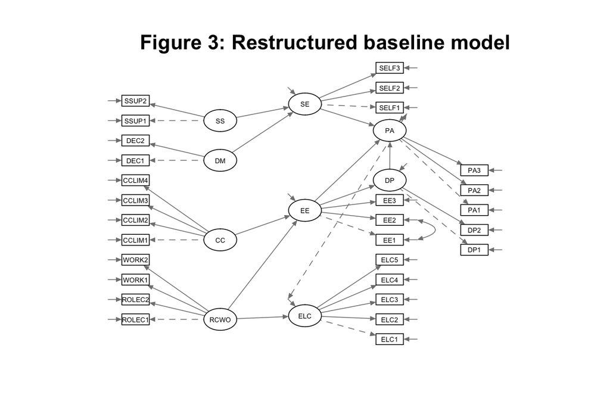

### Exercise 6.2

Let us combine the groups and specify the common baseline (configural) model and draw the graphs.

```
## lavaan 0.6-3 ended normally after 116 iterations
##
##   Optimization method                           NLMINB
##   Number of free parameters                        200
##
##   Number of observations per group
##   calibration                                      602
##   validation                                       601
##
##   Estimator                                         ML      Robust
##   Model Fit Test Statistic                    1622.707    1484.062
##   Degrees of freedom                               668         668
##   P-value (Chi-square)                           0.000       0.000
##   Scaling correction factor                                  1.093
##     for the Satorra-Bentler correction
##
## Chi-square for each group:
##
##   calibration                                  789.858     722.373
##   validation                                   832.848     761.689
```

Fit indices

| Model | Chi.square | Df | p.value | CFI | TLI | RMSEA | SRMR |
| --- | --- | --- | --- | --- | --- | --- | --- |
| Baseline model | 721.5229 | 334 | 0 | 0.951 | 0.944 | 0.046 | 0.053 |
| Configural model | 1484.0618 | 668 | 0 | 0.949 | 0.942 | 0.047 | 0.056 |

The model fit indices in this multigroup configural model are almost as good (but not exactly) as in the calibration group’s baseline model.

### Exercise 6.3

In the invariant model we fix factor means to zero.

```
## lavaan 0.6-3 ended normally after 178 iterations
##
##   Optimization method                           NLMINB
##   Number of free parameters                        200
##   Number of equality constraints                    56
##
##   Number of observations per group
##   calibration                                      602
##   validation                                       601
##
##   Estimator                                         ML      Robust
##   Model Fit Test Statistic                    1682.811    1544.170
##   Degrees of freedom                               724         724
##   P-value (Chi-square)                           0.000       0.000
##   Scaling correction factor                                  1.090
##     for the Satorra-Bentler correction
##
## Chi-square for each group:
##
##   calibration                                  820.825     753.200
##   validation                                   861.986     790.970
```

Fit indices

| Model | Chi.square | Df | p.value | CFI | TLI | RMSEA | SRMR |
| --- | --- | --- | --- | --- | --- | --- | --- |
| Configural model | 1484.062 | 668 | 0 | 0.949 | 0.942 | 0.047 | 0.056 |
| Invariant model | 1544.170 | 724 | 0 | 0.949 | 0.946 | 0.045 | 0.058 |

The model fit indices are quite similar.

```
## Scaled Chi Square Difference Test (method = "satorra.bentler.2001")
##
##           Df   AIC   BIC  Chisq Chisq diff Df diff Pr(>Chisq)
## fit.conf 668 68153 69172 1622.7
## fit.inv  724 68101 68835 1682.8      57.44      56     0.4216
```

The model that was specified step by step with the calibration group seems to have a good fit with the validation group also. It seems that the model is rather well built since the performed changes are not significant.